# Impact of Quarterback Rushing on NFL Games

## Introduction

In this project, we investigate the effect of quarterback statistics on NFL team performance. We chose to isolate quarterback rushing yards and passer rating. Passer rating is an important statistic to observe as it takes into account completions, touchdowns, yards and interceptions.

The specific questions we analyze here are: How does rushing yards of a quarterback affect his passer rating each game(or season)? Which statistic is more likely to determine a team winning the game or having a good season.

We will investigate the seasonal passer’s rating and per game passer’s rating of quarterbacks, seasonal average and per game rushing yards of quarterbacks, and game results of each team (win, lose, tie). All data are in NFL 2020-2021 season, both regular season and playoff.

We predict that quarterback passer rating is inversely correlated with rushing yards and passer rating is a better statistic in determining if a team is likely to win a game or have a successful season.

## Background

In recent years in NFL, more quarterback rushing was observed. The are offensive stratgies that rely on quarterback rushing and also quarterbacks can run we flaws in defense is observed. Qarterback rushing indeed adds more unpredictability to the offense, and it is reasonable to believe that even though rushing yards is not a parameter taken into account for passer’s rating, it might still improve quarterbacks passer’s rating by ditracting the defense to prevent rushing and creating more spaces for the quarterback to pass the ball. In order to better understand how exactly will quarterback rushing affect passer’s rating and impact the game, we carried out this analysis.

Our dataset was collected from stathead.com and presents the rushing yards and passer rating of many quarterbacks in the NFL. The data will be analyzed on a per season and per game basis. The per game basis takes into account a single season (year of season) and attempts to uncover if there is a correlation between in game wins and passer rating. For per season analysis, a good season is defined as making the playoffs.

It’s important to know how the passer rating is calculated so we can better understand where the correlation may be coming from. In the NFL, the passer rating is a combined calculation of a quarterback’s passing attempts, completions, passing yards, touchdown passes, and interceptions. This is calculated for every quarterback each game. What is interesting here is that the rushing yards of a quarterback is not included in the formula for passer’s rating.

$$Passer Rating = (\frac{(\frac{COMP}{ATT} - .3)*5 + (\frac{YARDS}{ATT} - 3)*.25 + (\frac{TD}{ATT})*20 + 2.375 - (\frac{INT}{ATT} *25)}{6})*100$$
Variables in this formula are COMP: completions, ATT: passing attempts, YARDS: passing yards, TD: passing touchdowns, and INT: interceptions.

Some underlying factors that may adversely affect our interpretation of this data could be things like injuries, substitutions, or anything else that may prevent the quarterback from playing the full game and therefore affect the passer rating or the outcome of the game in some unforeseen way.

In the rest of this report we will focus on analyzing the correlation between passer rating and the quarterback’s rushing yards and possibly some other factors as well. We will also use inference to determine which is a better statistic to use in order to accurately predict if a team will have a good season or win the game.

## Analysis

After we downloaded our data from stathead.com, we first tried the direct approach to address the correlation between passer’s rating and rushing yards for a quarterback by performing a least square linear fitting. After tidying up our raw data, We made two scatter plots per season and per game of passer’s rating vs. rushing yards. A linear regression line is added to the figures.

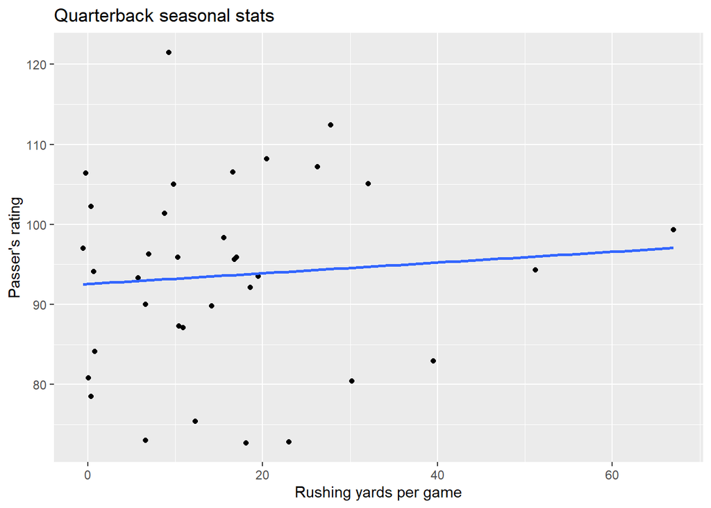

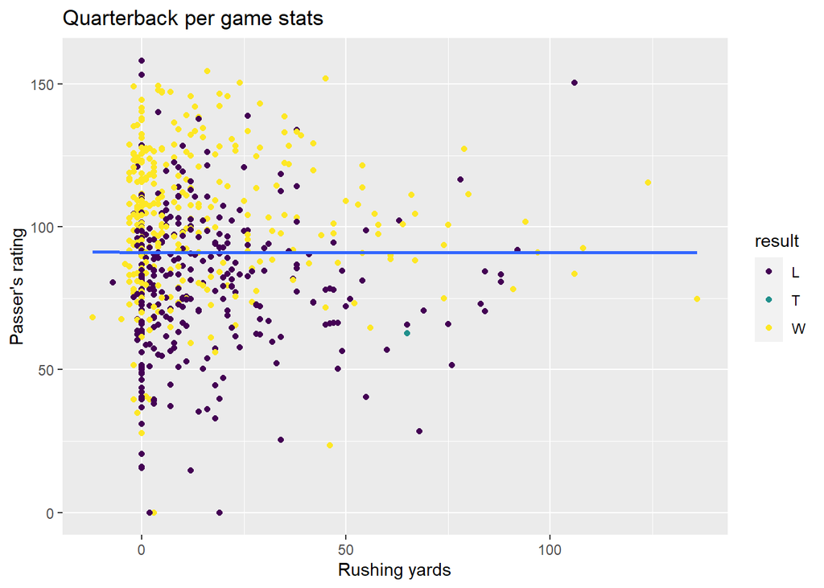

The extremely flat regression line and the small correlation coefficient suggest that there is no obvious way by which passer’s rating co-vary with rushing yards.Therefore, we seek to find some other ways how rushing yards might have impact on the games by investigating game results and rushing yards/passer’s rating.

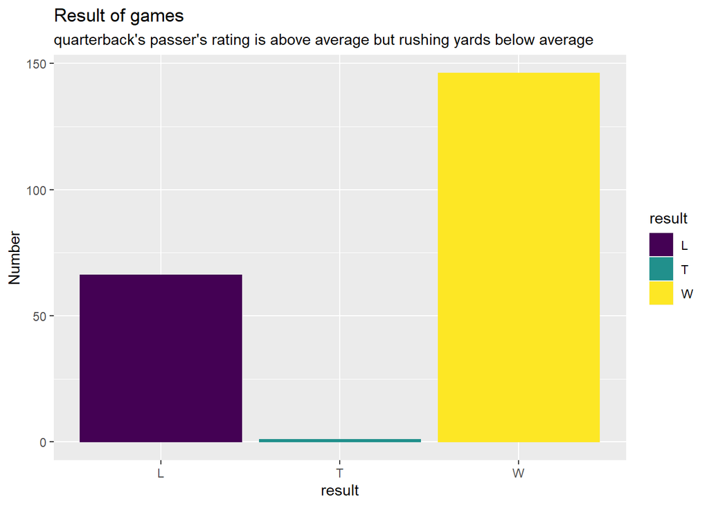

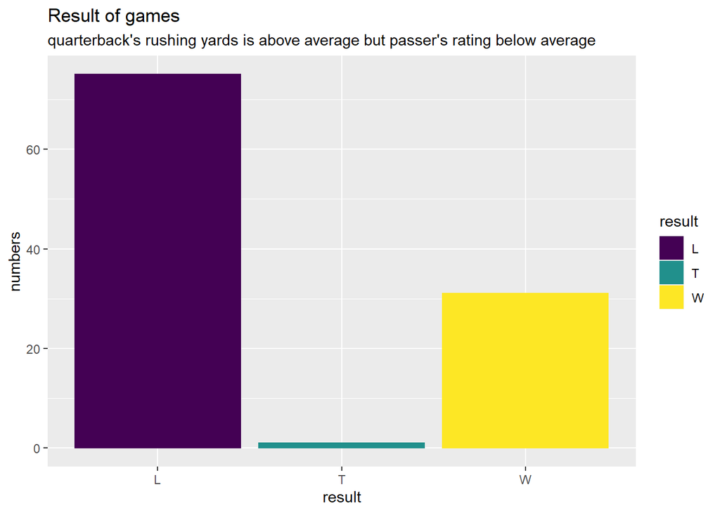

From the bar plot, we observed that when quaterback’s passer’s rating is above average but rushing yards below average, there is still more wins than losses, while when the quaterback’s rushing yards is above average but passer’s rating below average, losses outnumbers the wins.

In order to try to find a relationship between the number of wins and the passer’s rating/rushing yards we need to plot the data and fit a line to the data. In order to determine which line would fit the best to the data we conducted a residual test for both of the relationships. We used number of wins as the response variable and passer rating/rushing yards for the explanatory variable.

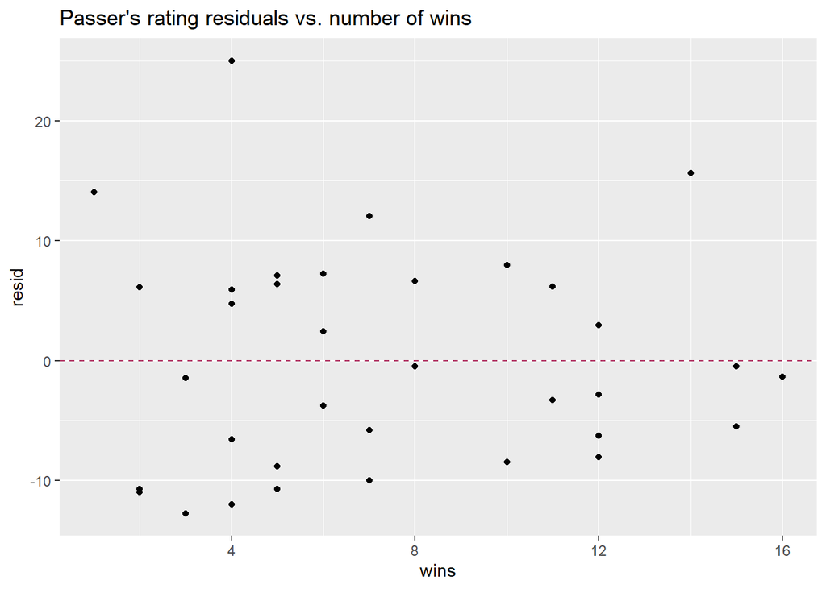

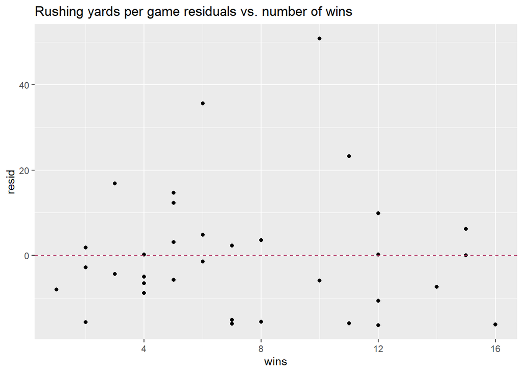

Both of the dataset resemble a random spread around the x-axis. With this data, we can conclude that a least squares regression line is appropriate for this data. We then plotted the number of wins vs. passer’s rating and the number of wins vs. rushing yards. By doing so, we were trying to find the correlation between the number of wins and passer’s rating/rushing yards.

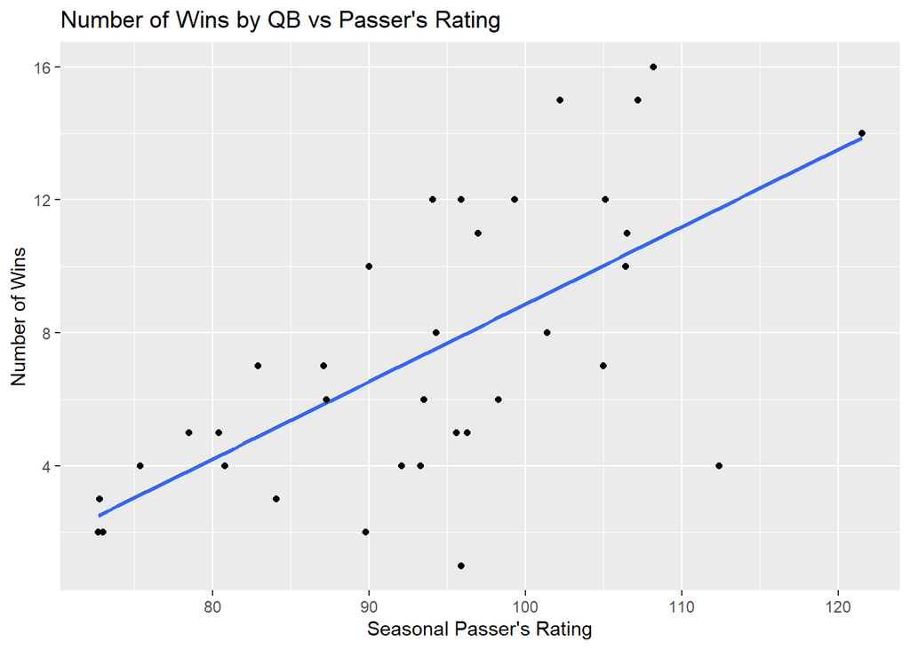

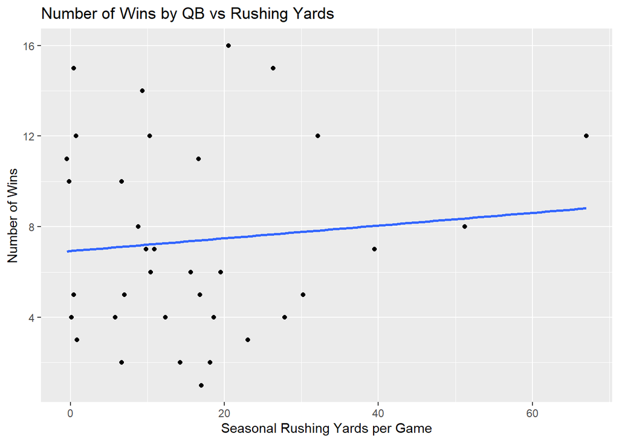

We noticed that the correlation coefficient of number of wins vs. passer’s rating is 0.66, much higher than 0.10 of number of wins vs. rushing yards. But to further investigate the difference in correlation, we compared the two correlation coefficient using paired.r function from psych package. The resulted p-value is 0.0060. Our interpretation is that the positive correlation between number of wins and passer’s rating is significantly stronger than the positive correlation between number of wins and rushing yards per game.

Then we investigated the win probability when the quarter back had an above average passer’s rating in that game or below average. We performed a two proportion z-test comparing the win probability under the two situations and we did the same thing to investigate the difference in win probability when the rushing yards of the quarter back in that game is above or below average.We The hypotheses we were testing are:

$$H_0: P_{win, ~above~average~passer's~rating} = P_{win, ~below ~average ~passer's ~rating}\\
H_a: P_{win,~above~average ~passer's ~rating} > P_{win, ~below ~average ~passer's ~rating}$$
and the same for rushing yards:
$$H_0: P_{win, ~above ~average ~rushing ~yards} = P_{win, ~below ~average ~rushing ~yards}\\
H_a: P_{win, ~above ~average ~rushing ~yards} > P_{win, ~below ~average ~rushing ~yards}$$

After performing two proportion z-tests, we found a p-value that is too little to be reported by RStudio (<0.00001) when comparing the probability of win when the passer’s rating is above or below the average. On the other hand, we found a p-value of $0.80$ when comparing the probability of win when the rushing yards is above or below average. The p-values means that the win probability when the quarterback’s passer’s rating is above average is significantly higher than when the quarterback’s passer’s rating is below average. While on the other hand, having the above average rushing yards per game have no significant affect on win probability.

## Discussion

When looking at the results of our graphs, starting with the quarterback’s performance by season, there is not a strong relationship between the quarterback’s passer rating and that quarterback’s rushing yards for each season. This is shown in our first graph where the linear regression of the relationship between passer rating and rushing yards is slightly positive, but the slope is still rather close to zero.

There is a similar result when we look at the same comparison but instead using data of the quarterback separated by game instead of season. This relationship shows no correlation at all with the slope of the linear regression line extremely flat and therefore extremely close to zero. Therefore, we can say that there is no obvious pattern by which the passer’s rating co-vary with rushing yards.

The following bar graphs show the relationship between a team’s winning record and a quarterback’s statistics, more specifically the quarterback’s passer rating and rushing yards. The first bar graph looks at how teams performed with a quarterback who had a passer rating above average and rushing yards below average. This shows that there was a much higher percentage of wins when this was the case for the quarterback’s performance.

The next graph tests the opposite, with a quarterback with a below average passer rating and above average rushing yards. Interestingly, when a quarterback has a lot of rushing yards and a low passer rating, the team’s winning percentage suffers. This two graphs might be a direct visualization of how much more impact passer’s rating have on the game than rushing yards.

The next graph shows the correlation between a quarterback’s seasonal passer rating and their team’s number of wins in that season. Unsurprisingly there is a strong correlation between these two variables due to the fact that when a quarterback performs well, the team in turn does well.

We also compared the quarterback’s rushing yards on the season to the number of wins each quarterback’s team had on the season. This graph shows a slight positive correlation suggesting that the more rushing yards a quarterback has on the season, the more likely their team is to win. This does seem to disagree with our previous findings on the second bar graph, with a low passer rating and high rushing yards, but it does provide evidence to suggest that passer’s rating has more impact on winning the game.

The assumptions made in the z-tests here were that all trials had 2 outcomes (win or loss, we did not consider ties), all games were predetermined, each game/trial was independent, and there was the same probability of winning a game each trial. Shortcomings of the z-test analysis come with the last two assumptions. First, each game/trail was not independent. If one team loses a game, then the other team wins. However, this would double our available data as results of separate games are still independent. Passer rating is an independent variable here as one quarterback’s passing rating does not affect the other quarterback’s rating. It is only the result of the games which are dependent for each data point where the game matches. Furthermore, the probability of winning a game each game was not the same for each trial. Some teams have better players, coaches, and chemistry than others. It is impossible to accurately predict the probability of one team beating another in the NFL, but estimates can be made.

The results of the z-tests lead to another question of if the results of the z-test would stay the same if we looked at only games with the same spread. This way, we are using the probability estimates made by some official betting organization to keep the probability of winning a game the same for each trial.

In conclusion, we observed that there is no significant correlation between a quarterback’s passer’s rating and rushing yards. Also, at this time, passer’s rating is still a better predictor of game victory. In other words, although quarterback rushing is getting popular in recent years, the impact of quarterback rushing in games is not as significant as passing.

## Reference

All data are aquired from https://stathead.com/football/